# Multivariate Assignment

2023-02-19

```r
library(vegan)
data(dune)
data(dune.env)
?dune
```

```
## starting httpd help server ...
```

```
##  done
```

# 1. Conduct an indirect ordination on the dune plant community. Specifically, visually examine a NMDS plot using the bray-curtis distance metric. # Below is some code to help you develop a potential plot that emphasizes the role of the environmental variable “Moisture”. Describe how you interpret the graphic. What is the goal of creating such a plot? Does this analysis suggest any interesting findings with respect to the dune vegetation?

```r
# NMDS

dune_mds <- metaMDS(dune)
```

```
## *** Best solution repeated 1 times
```

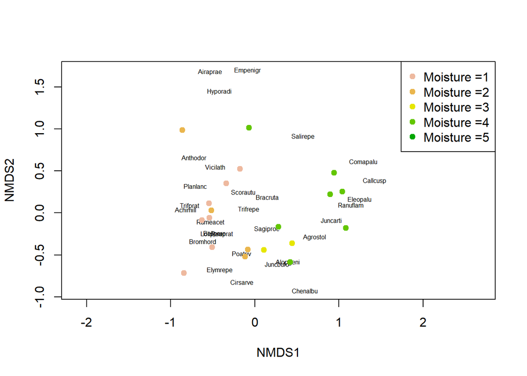

```r
plot(dune_mds, type='n')
 text(dune_mds, 'sp', cex=.5)
 # generate vector of colors
 color_vect = rev(terrain.colors(6))[-1]
 points(dune_mds, 'sites', pch=19,
        col=color_vect[dune.env$Moisture])
 legend('topright', paste("Moisture =", 1:5, sep=''),
        col=color_vect, pch=19)
```

```r
 # It appears that there is a clear distinction between higher moisture levels and lower moisture levels. It is clear that certain species are observed more in areas with higher miosture levels (Callcusp, Eleopalu), while others are observed more often in low moisture (Trifprat, Rumeacet). This graphs helps us to visualize any patterns between species observations and moisture levels.
```

# Carry out a direct ordination using CCA in order to test any potential hypotheses that you developed after examining the MDS plot. Specifically, carry out a test of the entire model (i.e., including all constrained axes) and also carry out tests at the scale of individual explanatory variables you included in your model if you included more than one variable. Plot your results.

```r
# CCA
cca_dune <- cca(dune ~ . , data = dune.env)
cca_dune
```

```
## Call: cca(formula = dune ~ A1 + Moisture + Management + Use + Manure,
## data = dune.env)
##
##               Inertia Proportion Rank
## Total          2.1153     1.0000
## Constrained    1.5032     0.7106   12
## Unconstrained  0.6121     0.2894    7
## Inertia is scaled Chi-square
## Some constraints or conditions were aliased because they were redundant
##
## Eigenvalues for constrained axes:
##   CCA1   CCA2   CCA3   CCA4   CCA5   CCA6   CCA7   CCA8   CCA9  CCA10  CCA11
## 0.4671 0.3410 0.1761 0.1532 0.0953 0.0703 0.0589 0.0499 0.0318 0.0260 0.0228
##  CCA12
## 0.0108
##
## Eigenvalues for unconstrained axes:
##     CA1     CA2     CA3     CA4     CA5     CA6     CA7
## 0.27237 0.10876 0.08975 0.06305 0.03489 0.02529 0.01798
```

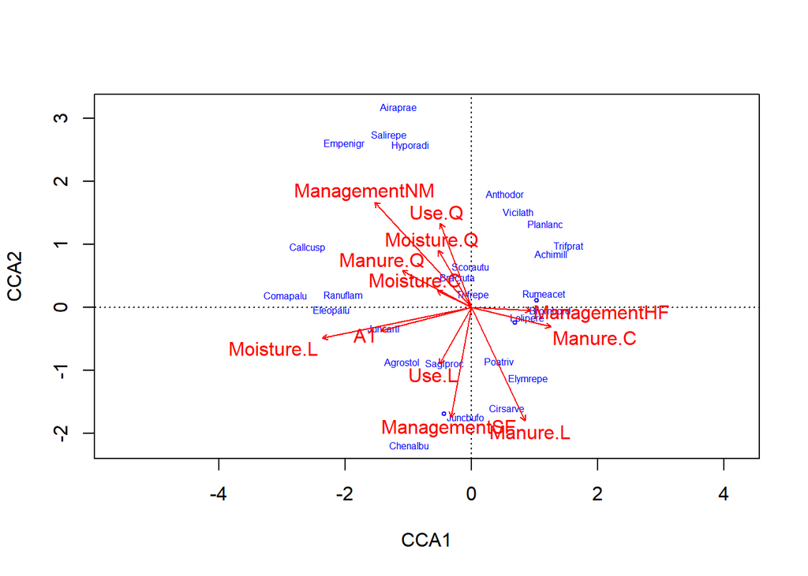

```r
plot(cca_dune, type='n', scaling=1)
orditorp(cca_dune, display='sp', cex=0.5, scaling=1, col='blue')
text(cca_dune, display='bp', col='red')
```

```r
# RDAs
rda_dune <- rda(dune ~ Moisture, data = dune.env)
rda_dune
```

```
## Call: rda(formula = dune ~ Moisture, data = dune.env)
##
##               Inertia Proportion Rank
## Total         84.1237     1.0000
## Constrained   27.4865     0.3267    3
## Unconstrained 56.6372     0.6733   16
## Inertia is variance
##
## Eigenvalues for constrained axes:
##   RDA1   RDA2   RDA3
## 19.067  5.764  2.656
##
## Eigenvalues for unconstrained axes:
##    PC1    PC2    PC3    PC4    PC5    PC6    PC7    PC8    PC9   PC10   PC11
## 15.077  9.472  6.655  5.264  4.986  3.548  3.180  2.435  1.767  1.545  0.997
##   PC12   PC13   PC14   PC15   PC16
##  0.646  0.406  0.296  0.197  0.166
```

```r
RsquareAdj(rda_dune)
```

```
## $r.squared
## [1] 0.3267387
##
## $adj.r.squared
## [1] 0.2005022
```

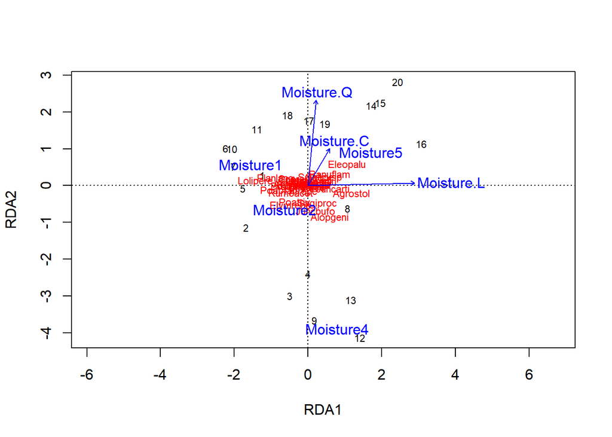

```r
plot(rda_dune)
```

```r
rda_dune2 <- rda(dune ~ Moisture + Management, data = dune.env)
rda_dune2
```

```
## Call: rda(formula = dune ~ Moisture + Management, data = dune.env)
##
##               Inertia Proportion Rank
## Total         84.1237     1.0000
## Constrained   46.4249     0.5519    6
## Unconstrained 37.6988     0.4481   13
## Inertia is variance
##
## Eigenvalues for constrained axes:
##   RDA1   RDA2   RDA3   RDA4   RDA5   RDA6
## 21.588 14.075  4.123  3.163  2.369  1.107
##
## Eigenvalues for unconstrained axes:
##   PC1   PC2   PC3   PC4   PC5   PC6   PC7   PC8   PC9  PC10  PC11  PC12  PC13
## 8.241 7.138 5.355 4.409 3.143 2.770 1.878 1.741 0.952 0.909 0.627 0.311 0.227
```